# Risk Factor Analysis

## Outcome Variable

**Outcome Variable:** sstunted

## Predictor Variables

**Intervention Variable:** meducyrs

**Adjustment Set:**

unadjusted

## Stratifying Variables

The analysis was stratified on these variable(s):

- agecat
- studyid

The following strata were considered:

- agecat: 12 months, studyid: ki0047075b-MAL-ED
- agecat: 12 months, studyid: ki1000108-CMC-V-BCS-2002
- agecat: 12 months, studyid: ki1000108-IRC
- agecat: 12 months, studyid: ki1000109-EE
- agecat: 12 months, studyid: ki1000304b-SAS-FoodSuppl
- agecat: 12 months, studyid: ki1017093-NIH-Birth
- agecat: 12 months, studyid: ki1017093b-PROVIDE
- agecat: 12 months, studyid: ki1017093c-NIH-Crypto
- agecat: 12 months, studyid: ki1066203-TanzaniaChild2
- agecat: 12 months, studyid: ki1112895-Guatemala BSC
- agecat: 12 months, studyid: ki1113344-GMS-Nepal
- agecat: 12 months, studyid: ki1126311-ZVITAMBO
- agecat: 12 months, studyid: ki1135781-COHORTS
- agecat: 12 months, studyid: ki1148112-LCNI-5
- agecat: 18 months, studyid: ki0047075b-MAL-ED
- agecat: 18 months, studyid: ki1000108-CMC-V-BCS-2002
- agecat: 18 months, studyid: ki1000108-IRC
- agecat: 18 months, studyid: ki1000109-EE
- agecat: 18 months, studyid: ki1000304b-SAS-FoodSuppl
- agecat: 18 months, studyid: ki1017093-NIH-Birth
- agecat: 18 months, studyid: ki1017093b-PROVIDE
- agecat: 18 months, studyid: ki1017093c-NIH-Crypto
- agecat: 18 months, studyid: ki1066203-TanzaniaChild2
- agecat: 18 months, studyid: ki1113344-GMS-Nepal
- agecat: 18 months, studyid: ki1126311-ZVITAMBO
- agecat: 18 months, studyid: ki1135781-COHORTS
- agecat: 18 months, studyid: ki1148112-LCNI-5
- agecat: 24 months, studyid: ki0047075b-MAL-ED
- agecat: 24 months, studyid: ki1000108-CMC-V-BCS-2002
- agecat: 24 months, studyid: ki1000108-IRC
- agecat: 24 months, studyid: ki1017093-NIH-Birth
- agecat: 24 months, studyid: ki1017093b-PROVIDE
- agecat: 24 months, studyid: ki1017093c-NIH-Crypto
- agecat: 24 months, studyid: ki1066203-TanzaniaChild2
- agecat: 24 months, studyid: ki1113344-GMS-Nepal
- agecat: 24 months, studyid: ki1126311-ZVITAMBO
- agecat: 24 months, studyid: ki1135781-COHORTS
- agecat: 24 months, studyid: ki1148112-LCNI-5
- agecat: 3 months, studyid: ki0047075b-MAL-ED
- agecat: 3 months, studyid: ki1000108-CMC-V-BCS-2002
- agecat: 3 months, studyid: ki1000108-IRC
- agecat: 3 months, studyid: ki1000109-EE
- agecat: 3 months, studyid: ki1000304b-SAS-FoodSuppl
- agecat: 3 months, studyid: ki1017093-NIH-Birth
- agecat: 3 months, studyid: ki1017093b-PROVIDE
- agecat: 3 months, studyid: ki1017093c-NIH-Crypto
- agecat: 3 months, studyid: ki1066203-TanzaniaChild2
- agecat: 3 months, studyid: ki1112895-Guatemala BSC
- agecat: 3 months, studyid: ki1113344-GMS-Nepal
- agecat: 3 months, studyid: ki1126311-ZVITAMBO
- agecat: 3 months, studyid: ki1135781-COHORTS
- agecat: 6 months, studyid: ki0047075b-MAL-ED
- agecat: 6 months, studyid: ki1000108-CMC-V-BCS-2002
- agecat: 6 months, studyid: ki1000108-IRC
- agecat: 6 months, studyid: ki1000109-EE
- agecat: 6 months, studyid: ki1000304b-SAS-FoodSuppl
- agecat: 6 months, studyid: ki1017093-NIH-Birth
- agecat: 6 months, studyid: ki1017093b-PROVIDE
- agecat: 6 months, studyid: ki1017093c-NIH-Crypto
- agecat: 6 months, studyid: ki1066203-TanzaniaChild2
- agecat: 6 months, studyid: ki1112895-Guatemala BSC
- agecat: 6 months, studyid: ki1113344-GMS-Nepal
- agecat: 6 months, studyid: ki1126311-ZVITAMBO
- agecat: 6 months, studyid: ki1135781-COHORTS
- agecat: 6 months, studyid: ki1148112-LCNI-5
- agecat: 9 months, studyid: ki0047075b-MAL-ED
- agecat: 9 months, studyid: ki1000108-CMC-V-BCS-2002
- agecat: 9 months, studyid: ki1000108-IRC
- agecat: 9 months, studyid: ki1000109-EE
- agecat: 9 months, studyid: ki1000304b-SAS-FoodSuppl
- agecat: 9 months, studyid: ki1017093-NIH-Birth
- agecat: 9 months, studyid: ki1017093b-PROVIDE
- agecat: 9 months, studyid: ki1017093c-NIH-Crypto
- agecat: 9 months, studyid: ki1066203-TanzaniaChild2
- agecat: 9 months, studyid: ki1112895-Guatemala BSC
- agecat: 9 months, studyid: ki1113344-GMS-Nepal
- agecat: 9 months, studyid: ki1126311-ZVITAMBO
- agecat: 9 months, studyid: ki1135781-COHORTS
- agecat: 9 months, studyid: ki1148112-LCNI-5
- agecat: Birth, studyid: ki0047075b-MAL-ED
- agecat: Birth, studyid: ki1000108-CMC-V-BCS-2002
- agecat: Birth, studyid: ki1000108-IRC
- agecat: Birth, studyid: ki1000109-EE
- agecat: Birth, studyid: ki1017093-NIH-Birth
- agecat: Birth, studyid: ki1017093c-NIH-Crypto
- agecat: Birth, studyid: ki1126311-ZVITAMBO
- agecat: Birth, studyid: ki1135781-COHORTS

### Dropped Strata

Some strata were dropped due to rare outcomes:

- agecat: Birth, studyid: ki0047075b-MAL-ED
- agecat: Birth, studyid: ki1000108-CMC-V-BCS-2002
- agecat: Birth, studyid: ki1000108-IRC
- agecat: Birth, studyid: ki1000109-EE
- agecat: Birth, studyid: ki1017093-NIH-Birth
- agecat: Birth, studyid: ki1017093c-NIH-Crypto
- agecat: 3 months, studyid: ki1000108-CMC-V-BCS-2002
- agecat: 3 months, studyid: ki1000108-IRC
- agecat: 3 months, studyid: ki1000109-EE
- agecat: 3 months, studyid: ki1000304b-SAS-FoodSuppl
- agecat: 3 months, studyid: ki1017093-NIH-Birth
- agecat: 3 months, studyid: ki1017093b-PROVIDE
- agecat: 3 months, studyid: ki1017093c-NIH-Crypto
- agecat: 3 months, studyid: ki1066203-TanzaniaChild2
- agecat: 3 months, studyid: ki1112895-Guatemala BSC
- agecat: 3 months, studyid: ki1113344-GMS-Nepal
- agecat: 3 months, studyid: ki1126311-ZVITAMBO
- agecat: 6 months, studyid: ki0047075b-MAL-ED
- agecat: 6 months, studyid: ki1000108-CMC-V-BCS-2002
- agecat: 6 months, studyid: ki1000108-IRC
- agecat: 6 months, studyid: ki1000109-EE
- agecat: 6 months, studyid: ki1000304b-SAS-FoodSuppl
- agecat: 6 months, studyid: ki1017093-NIH-Birth
- agecat: 6 months, studyid: ki1017093b-PROVIDE
- agecat: 6 months, studyid: ki1017093c-NIH-Crypto
- agecat: 6 months, studyid: ki1066203-TanzaniaChild2
- agecat: 6 months, studyid: ki1112895-Guatemala BSC
- agecat: 6 months, studyid: ki1113344-GMS-Nepal
- agecat: 6 months, studyid: ki1126311-ZVITAMBO
- agecat: 6 months, studyid: ki1148112-LCNI-5
- agecat: 9 months, studyid: ki0047075b-MAL-ED
- agecat: 9 months, studyid: ki1000108-CMC-V-BCS-2002
- agecat: 9 months, studyid: ki1000108-IRC
- agecat: 9 months, studyid: ki1000109-EE
- agecat: 9 months, studyid: ki1000304b-SAS-FoodSuppl
- agecat: 9 months, studyid: ki1017093-NIH-Birth
- agecat: 9 months, studyid: ki1017093b-PROVIDE
- agecat: 9 months, studyid: ki1017093c-NIH-Crypto
- agecat: 9 months, studyid: ki1066203-TanzaniaChild2
- agecat: 9 months, studyid: ki1112895-Guatemala BSC
- agecat: 9 months, studyid: ki1113344-GMS-Nepal
- agecat: 9 months, studyid: ki1126311-ZVITAMBO
- agecat: 9 months, studyid: ki1148112-LCNI-5
- agecat: 12 months, studyid: ki1000108-CMC-V-BCS-2002
- agecat: 12 months, studyid: ki1000108-IRC
- agecat: 12 months, studyid: ki1000109-EE
- agecat: 12 months, studyid: ki1000304b-SAS-FoodSuppl
- agecat: 12 months, studyid: ki1017093-NIH-Birth
- agecat: 12 months, studyid: ki1017093b-PROVIDE
- agecat: 12 months, studyid: ki1066203-TanzaniaChild2
- agecat: 12 months, studyid: ki1112895-Guatemala BSC
- agecat: 12 months, studyid: ki1113344-GMS-Nepal
- agecat: 12 months, studyid: ki1126311-ZVITAMBO
- agecat: 12 months, studyid: ki1148112-LCNI-5
- agecat: 18 months, studyid: ki1000108-CMC-V-BCS-2002
- agecat: 18 months, studyid: ki1000108-IRC
- agecat: 18 months, studyid: ki1000109-EE
- agecat: 18 months, studyid: ki1000304b-SAS-FoodSuppl
- agecat: 18 months, studyid: ki1017093-NIH-Birth
- agecat: 18 months, studyid: ki1017093b-PROVIDE
- agecat: 18 months, studyid: ki1066203-TanzaniaChild2
- agecat: 18 months, studyid: ki1113344-GMS-Nepal
- agecat: 18 months, studyid: ki1126311-ZVITAMBO
- agecat: 18 months, studyid: ki1148112-LCNI-5
- agecat: 24 months, studyid: ki0047075b-MAL-ED
- agecat: 24 months, studyid: ki1000108-CMC-V-BCS-2002
- agecat: 24 months, studyid: ki1000108-IRC
- agecat: 24 months, studyid: ki1017093-NIH-Birth
- agecat: 24 months, studyid: ki1017093b-PROVIDE
- agecat: 24 months, studyid: ki1066203-TanzaniaChild2
- agecat: 24 months, studyid: ki1113344-GMS-Nepal
- agecat: 24 months, studyid: ki1126311-ZVITAMBO
- agecat: 24 months, studyid: ki1148112-LCNI-5

## Methods Detail

We’re interested in the causal parameters $E[Y_a]$ for all values of $a \in \mathcal{A}$. These parameters represent the mean outcome if, possibly contrary to fact, we intervened to set all units to have $A=a$. Under the randomization and positivity assumptions, these are identified by the statistical parameters $\psi_a=E_W[E_{Y|A,W}(Y|A=a,W)]$. In addition, we’re interested in the mean of $Y$, $E[Y]$ under no intervention (the observed mean). We will estimate these parameters by using SuperLearner to fit the relevant likelihood factors – $E_{Y|A,W}(Y|A=a,W)$ and $p(A=a|W)$, and then updating our likelihood fit using a joint TMLE.

For unadjusted analyses ($W=\{\}$), initial likelihoods were estimated using Lrnr_glm to estimate the simple $E(Y|A)$ and Lrnr_mean to estimate $p(A)$. For adjusted analyses, a small library containing Lrnr_glmnet, Lrnr_xgboost, and Lrnr_mean was used.

Having estimated these parameters, we will then use the delta method to estimate relative risks and attributable risks relative to a prespecified baseline level of $A$.

# Results Detail

## Results Plots

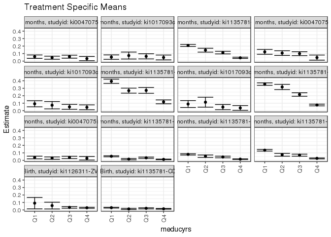

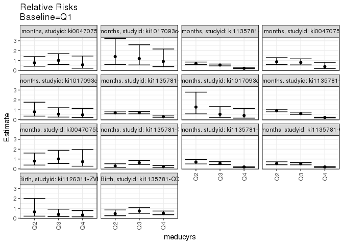

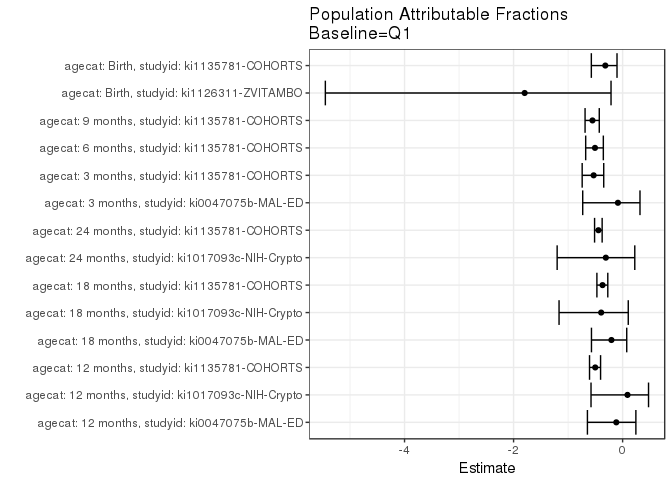

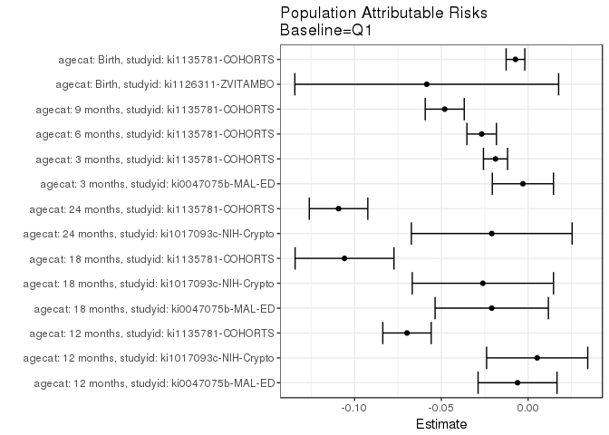

## Data Summary

| agecat | studyid | A | n | nA | nAY0 | nAY1 |
| --- | --- | --- | --- | --- | --- | --- |
| Birth | ki0047075b-MAL-ED | Q1 | 1395 | 398 | 389 | 9 |
| Birth | ki0047075b-MAL-ED | Q2 | 1395 | 394 | 385 | 9 |
| Birth | ki0047075b-MAL-ED | Q3 | 1395 | 439 | 420 | 19 |
| Birth | ki0047075b-MAL-ED | Q4 | 1395 | 164 | 161 | 3 |
| Birth | ki1000108-CMC-V-BCS-2002 | Q1 | 90 | 15 | 15 | 0 |
| Birth | ki1000108-CMC-V-BCS-2002 | Q2 | 90 | 50 | 47 | 3 |
| Birth | ki1000108-CMC-V-BCS-2002 | Q3 | 90 | 22 | 22 | 0 |
| Birth | ki1000108-CMC-V-BCS-2002 | Q4 | 90 | 3 | 3 | 0 |
| Birth | ki1000108-IRC | Q1 | 388 | 176 | 169 | 7 |
| Birth | ki1000108-IRC | Q2 | 388 | 99 | 93 | 6 |
| Birth | ki1000108-IRC | Q3 | 388 | 103 | 100 | 3 |
| Birth | ki1000108-IRC | Q4 | 388 | 10 | 10 | 0 |
| Birth | ki1000109-EE | Q1 | 2 | 2 | 2 | 0 |
| Birth | ki1000109-EE | Q2 | 2 | 0 | 0 | 0 |
| Birth | ki1000109-EE | Q3 | 2 | 0 | 0 | 0 |
| Birth | ki1000109-EE | Q4 | 2 | 0 | 0 | 0 |
| Birth | ki1000304b-SAS-FoodSuppl | Q1 | 0 | 0 | 0 | 0 |
| Birth | ki1000304b-SAS-FoodSuppl | Q2 | 0 | 0 | 0 | 0 |
| Birth | ki1000304b-SAS-FoodSuppl | Q3 | 0 | 0 | 0 | 0 |
| Birth | ki1000304b-SAS-FoodSuppl | Q4 | 0 | 0 | 0 | 0 |
| Birth | ki1017093-NIH-Birth | Q1 | 28 | 16 | 16 | 0 |
| Birth | ki1017093-NIH-Birth | Q2 | 28 | 10 | 10 | 0 |
| Birth | ki1017093-NIH-Birth | Q3 | 28 | 1 | 1 | 0 |
| Birth | ki1017093-NIH-Birth | Q4 | 28 | 1 | 1 | 0 |
| Birth | ki1017093b-PROVIDE | Q1 | 0 | 0 | 0 | 0 |
| Birth | ki1017093b-PROVIDE | Q2 | 0 | 0 | 0 | 0 |
| Birth | ki1017093b-PROVIDE | Q3 | 0 | 0 | 0 | 0 |
| Birth | ki1017093b-PROVIDE | Q4 | 0 | 0 | 0 | 0 |
| Birth | ki1017093c-NIH-Crypto | Q1 | 27 | 12 | 12 | 0 |
| Birth | ki1017093c-NIH-Crypto | Q2 | 27 | 4 | 4 | 0 |

[output cut: 362 more lines]

## Results Table

### Parameter: TSM

| agecat | studyid | intervention_level | baseline_level | estimate | ci_lower | ci_upper |
| --- | --- | --- | --- | --- | --- | --- |
| Birth | ki1126311-ZVITAMBO | Q1 | NA | 0.0909091 | 0.0149225 | 0.1668957 |
| Birth | ki1126311-ZVITAMBO | Q2 | NA | 0.0582524 | 0.0130130 | 0.1034918 |
| Birth | ki1126311-ZVITAMBO | Q3 | NA | 0.0339893 | 0.0233661 | 0.0446124 |
| Birth | ki1126311-ZVITAMBO | Q4 | NA | 0.0290323 | 0.0219671 | 0.0360975 |
| Birth | ki1135781-COHORTS | Q1 | NA | 0.0302487 | 0.0248738 | 0.0356235 |
| Birth | ki1135781-COHORTS | Q2 | NA | 0.0136476 | 0.0056373 | 0.0216580 |
| Birth | ki1135781-COHORTS | Q3 | NA | 0.0219328 | 0.0144170 | 0.0294487 |
| Birth | ki1135781-COHORTS | Q4 | NA | 0.0151939 | 0.0103996 | 0.0199882 |
| 3 months | ki0047075b-MAL-ED | Q1 | NA | 0.0377778 | 0.0201568 | 0.0553988 |
| 3 months | ki0047075b-MAL-ED | Q2 | NA | 0.0298851 | 0.0138794 | 0.0458908 |
| 3 months | ki0047075b-MAL-ED | Q3 | NA | 0.0383275 | 0.0226169 | 0.0540382 |
| 3 months | ki0047075b-MAL-ED | Q4 | NA | 0.0277778 | 0.0037631 | 0.0517924 |
| 3 months | ki1135781-COHORTS | Q1 | NA | 0.0541534 | 0.0472094 | 0.0610974 |
| 3 months | ki1135781-COHORTS | Q2 | NA | 0.0157068 | 0.0068896 | 0.0245240 |
| 3 months | ki1135781-COHORTS | Q3 | NA | 0.0336538 | 0.0243903 | 0.0429174 |
| 3 months | ki1135781-COHORTS | Q4 | NA | 0.0124079 | 0.0081354 | 0.0166804 |
| 6 months | ki1135781-COHORTS | Q1 | NA | 0.0795600 | 0.0710763 | 0.0880437 |
| 6 months | ki1135781-COHORTS | Q2 | NA | 0.0549451 | 0.0383911 | 0.0714990 |
| 6 months | ki1135781-COHORTS | Q3 | NA | 0.0446492 | 0.0338722 | 0.0554262 |
| 6 months | ki1135781-COHORTS | Q4 | NA | 0.0154028 | 0.0106058 | 0.0201999 |
| 9 months | ki1135781-COHORTS | Q1 | NA | 0.1349162 | 0.1237245 | 0.1461079 |
| 9 months | ki1135781-COHORTS | Q2 | NA | 0.0739726 | 0.0549854 | 0.0929598 |
| 9 months | ki1135781-COHORTS | Q3 | NA | 0.0687548 | 0.0550463 | 0.0824633 |
| 9 months | ki1135781-COHORTS | Q4 | NA | 0.0262123 | 0.0196669 | 0.0327577 |
| 12 months | ki0047075b-MAL-ED | Q1 | NA | 0.0585366 | 0.0358056 | 0.0812675 |
| 12 months | ki0047075b-MAL-ED | Q2 | NA | 0.0450000 | 0.0246777 | 0.0653223 |
| 12 months | ki0047075b-MAL-ED | Q3 | NA | 0.0589354 | 0.0388028 | 0.0790679 |
| 12 months | ki0047075b-MAL-ED | Q4 | NA | 0.0331126 | 0.0045636 | 0.0616615 |
| 12 months | ki1017093c-NIH-Crypto | Q1 | NA | 0.0528634 | 0.0237343 | 0.0819925 |
| 12 months | ki1017093c-NIH-Crypto | Q2 | NA | 0.0737705 | 0.0273535 | 0.1201874 |
| 12 months | ki1017093c-NIH-Crypto | Q3 | NA | 0.0631579 | 0.0285459 | 0.0977698 |
| 12 months | ki1017093c-NIH-Crypto | Q4 | NA | 0.0479042 | 0.0154908 | 0.0803176 |
| 12 months | ki1135781-COHORTS | Q1 | NA | 0.2087114 | 0.1948577 | 0.2225652 |
| 12 months | ki1135781-COHORTS | Q2 | NA | 0.1456860 | 0.1196793 | 0.1716927 |
| 12 months | ki1135781-COHORTS | Q3 | NA | 0.1127572 | 0.0949710 | 0.1305434 |
| 12 months | ki1135781-COHORTS | Q4 | NA | 0.0435597 | 0.0349011 | 0.0522184 |
| 18 months | ki0047075b-MAL-ED | Q1 | NA | 0.1230769 | 0.0904604 | 0.1556935 |
| 18 months | ki0047075b-MAL-ED | Q2 | NA | 0.1066667 | 0.0754126 | 0.1379207 |
| 18 months | ki0047075b-MAL-ED | Q3 | NA | 0.0990099 | 0.0729511 | 0.1250687 |
| 18 months | ki0047075b-MAL-ED | Q4 | NA | 0.0466667 | 0.0129005 | 0.0804328 |
| 18 months | ki1017093c-NIH-Crypto | Q1 | NA | 0.0923077 | 0.0516482 | 0.1329672 |
| 18 months | ki1017093c-NIH-Crypto | Q2 | NA | 0.0733945 | 0.0243989 | 0.1223901 |
| 18 months | ki1017093c-NIH-Crypto | Q3 | NA | 0.0514286 | 0.0186787 | 0.0841784 |
| 18 months | ki1017093c-NIH-Crypto | Q4 | NA | 0.0451613 | 0.0124443 | 0.0778783 |
| 18 months | ki1135781-COHORTS | Q1 | NA | 0.3930435 | 0.3648095 | 0.4212775 |
| 18 months | ki1135781-COHORTS | Q2 | NA | 0.2681481 | 0.2347233 | 0.3015730 |
| 18 months | ki1135781-COHORTS | Q3 | NA | 0.2712871 | 0.2325016 | 0.3100726 |
| 18 months | ki1135781-COHORTS | Q4 | NA | 0.1178451 | 0.0919118 | 0.1437784 |
| 24 months | ki1017093c-NIH-Crypto | Q1 | NA | 0.0890411 | 0.0427988 | 0.1352834 |
| 24 months | ki1017093c-NIH-Crypto | Q2 | NA | 0.1136364 | 0.0472629 | 0.1800098 |
| 24 months | ki1017093c-NIH-Crypto | Q3 | NA | 0.0482759 | 0.0133532 | 0.0831985 |
| 24 months | ki1017093c-NIH-Crypto | Q4 | NA | 0.0370370 | 0.0051491 | 0.0689250 |
| 24 months | ki1135781-COHORTS | Q1 | NA | 0.3556183 | 0.3389950 | 0.3722417 |
| 24 months | ki1135781-COHORTS | Q2 | NA | 0.3169643 | 0.2817823 | 0.3521463 |
| 24 months | ki1135781-COHORTS | Q3 | NA | 0.2163300 | 0.1929149 | 0.2397450 |
| 24 months | ki1135781-COHORTS | Q4 | NA | 0.0761950 | 0.0648819 | 0.0875081 |

### Parameter: E(Y)

| agecat | studyid | intervention_level | baseline_level | estimate | ci_lower | ci_upper |
| --- | --- | --- | --- | --- | --- | --- |
| Birth | ki1126311-ZVITAMBO | NA | NA | 0.0325015 | 0.0321980 | 0.0328049 |
| Birth | ki1135781-COHORTS | NA | NA | 0.0229607 | 0.0228124 | 0.0231089 |
| 3 months | ki0047075b-MAL-ED | NA | NA | 0.0347773 | 0.0345683 | 0.0349863 |
| 3 months | ki1135781-COHORTS | NA | NA | 0.0353604 | 0.0349718 | 0.0357490 |
| 6 months | ki1135781-COHORTS | NA | NA | 0.0527972 | 0.0522176 | 0.0533768 |
| 9 months | ki1135781-COHORTS | NA | NA | 0.0868741 | 0.0858450 | 0.0879031 |
| 12 months | ki0047075b-MAL-ED | NA | NA | 0.0524546 | 0.0520056 | 0.0529036 |
| 12 months | ki1017093c-NIH-Crypto | NA | NA | 0.0580737 | 0.0574023 | 0.0587450 |
| 12 months | ki1135781-COHORTS | NA | NA | 0.1389379 | 0.1373322 | 0.1405436 |
| 18 months | ki0047075b-MAL-ED | NA | NA | 0.1021127 | 0.1010036 | 0.1032217 |
| 18 months | ki1017093c-NIH-Crypto | NA | NA | 0.0662461 | 0.0647136 | 0.0677785 |
| 18 months | ki1135781-COHORTS | NA | NA | 0.2872777 | 0.2835878 | 0.2909676 |
| 24 months | ki1017093c-NIH-Crypto | NA | NA | 0.0680934 | 0.0655796 | 0.0706072 |
| 24 months | ki1135781-COHORTS | NA | NA | 0.2464031 | 0.2436158 | 0.2491904 |

### Parameter: RR

| agecat | studyid | intervention_level | baseline_level | estimate | ci_lower | ci_upper |
| --- | --- | --- | --- | --- | --- | --- |
| Birth | ki1126311-ZVITAMBO | Q2 | Q1 | 0.6407767 | 0.2047375 | 2.0054693 |
| Birth | ki1126311-ZVITAMBO | Q3 | Q1 | 0.3738819 | 0.1531725 | 0.9126159 |
| Birth | ki1126311-ZVITAMBO | Q4 | Q1 | 0.3193548 | 0.1337195 | 0.7626974 |
| Birth | ki1135781-COHORTS | Q2 | Q1 | 0.4511818 | 0.2443555 | 0.8330691 |
| Birth | ki1135781-COHORTS | Q3 | Q1 | 0.7250845 | 0.4928886 | 1.0666660 |
| Birth | ki1135781-COHORTS | Q4 | Q1 | 0.5023008 | 0.3496967 | 0.7214997 |
| 3 months | ki0047075b-MAL-ED | Q2 | Q1 | 0.7910751 | 0.3888439 | 1.6093856 |
| 3 months | ki0047075b-MAL-ED | Q3 | Q1 | 1.0145522 | 0.5452513 | 1.8877831 |
| 3 months | ki0047075b-MAL-ED | Q4 | Q1 | 0.7352941 | 0.2753220 | 1.9637276 |
| 3 months | ki1135781-COHORTS | Q2 | Q1 | 0.2900429 | 0.1630743 | 0.5158682 |
| 3 months | ki1135781-COHORTS | Q3 | Q1 | 0.6214541 | 0.4587021 | 0.8419520 |
| 3 months | ki1135781-COHORTS | Q4 | Q1 | 0.2291253 | 0.1586704 | 0.3308645 |
| 6 months | ki1135781-COHORTS | Q2 | Q1 | 0.6906116 | 0.5016902 | 0.9506752 |
| 6 months | ki1135781-COHORTS | Q3 | Q1 | 0.5612015 | 0.4310415 | 0.7306655 |
| 6 months | ki1135781-COHORTS | Q4 | Q1 | 0.1936004 | 0.1392972 | 0.2690730 |
| 9 months | ki1135781-COHORTS | Q2 | Q1 | 0.5482855 | 0.4186544 | 0.7180554 |
| 9 months | ki1135781-COHORTS | Q3 | Q1 | 0.5096110 | 0.4106321 | 0.6324478 |
| 9 months | ki1135781-COHORTS | Q4 | Q1 | 0.1942859 | 0.1493370 | 0.2527641 |
| 12 months | ki0047075b-MAL-ED | Q2 | Q1 | 0.7687500 | 0.4237589 | 1.3946056 |
| 12 months | ki0047075b-MAL-ED | Q3 | Q1 | 1.0068124 | 0.6002547 | 1.6887353 |
| 12 months | ki0047075b-MAL-ED | Q4 | Q1 | 0.5656733 | 0.2197355 | 1.4562337 |
| 12 months | ki1017093c-NIH-Crypto | Q2 | Q1 | 1.3954918 | 0.6046335 | 3.2207899 |
| 12 months | ki1017093c-NIH-Crypto | Q3 | Q1 | 1.1947368 | 0.5492392 | 2.5988605 |
| 12 months | ki1017093c-NIH-Crypto | Q4 | Q1 | 0.9061876 | 0.3786572 | 2.1686528 |
| 12 months | ki1135781-COHORTS | Q2 | Q1 | 0.6980260 | 0.5769772 | 0.8444705 |
| 12 months | ki1135781-COHORTS | Q3 | Q1 | 0.5402541 | 0.4552759 | 0.6410936 |
| 12 months | ki1135781-COHORTS | Q4 | Q1 | 0.2087079 | 0.1692487 | 0.2573667 |
| 18 months | ki0047075b-MAL-ED | Q2 | Q1 | 0.8666667 | 0.5838132 | 1.2865607 |
| 18 months | ki0047075b-MAL-ED | Q3 | Q1 | 0.8044554 | 0.5537244 | 1.1687195 |
| 18 months | ki0047075b-MAL-ED | Q4 | Q1 | 0.3791667 | 0.1754602 | 0.8193733 |
| 18 months | ki1017093c-NIH-Crypto | Q2 | Q1 | 0.7951070 | 0.3573399 | 1.7691707 |
| 18 months | ki1017093c-NIH-Crypto | Q3 | Q1 | 0.5571429 | 0.2568580 | 1.2084816 |
| 18 months | ki1017093c-NIH-Crypto | Q4 | Q1 | 0.4892473 | 0.2095623 | 1.1422042 |
| 18 months | ki1135781-COHORTS | Q2 | Q1 | 0.6822353 | 0.5908173 | 0.7877986 |
| 18 months | ki1135781-COHORTS | Q3 | Q1 | 0.6902217 | 0.5881678 | 0.8099830 |
| 18 months | ki1135781-COHORTS | Q4 | Q1 | 0.2998272 | 0.2378681 | 0.3779252 |
| 24 months | ki1017093c-NIH-Crypto | Q2 | Q1 | 1.2762238 | 0.5841052 | 2.7884483 |
| 24 months | ki1017093c-NIH-Crypto | Q3 | Q1 | 0.5421751 | 0.2225329 | 1.3209455 |
| 24 months | ki1017093c-NIH-Crypto | Q4 | Q1 | 0.4159544 | 0.1521849 | 1.1368938 |
| 24 months | ki1135781-COHORTS | Q2 | Q1 | 0.8913047 | 0.7901700 | 1.0053838 |
| 24 months | ki1135781-COHORTS | Q3 | Q1 | 0.6083206 | 0.5406660 | 0.6844410 |
| 24 months | ki1135781-COHORTS | Q4 | Q1 | 0.2142606 | 0.1833749 | 0.2503483 |

### Parameter: PAR

| agecat | studyid | intervention_level | baseline_level | estimate | ci_lower | ci_upper |
| --- | --- | --- | --- | --- | --- | --- |
| Birth | ki1126311-ZVITAMBO | Q1 | NA | -0.0584076 | -0.1343949 | 0.0175796 |
| Birth | ki1135781-COHORTS | Q1 | NA | -0.0072880 | -0.0126649 | -0.0019111 |
| 3 months | ki0047075b-MAL-ED | Q1 | NA | -0.0030005 | -0.0206227 | 0.0146218 |
| 3 months | ki1135781-COHORTS | Q1 | NA | -0.0187930 | -0.0257479 | -0.0118381 |
| 6 months | ki1135781-COHORTS | Q1 | NA | -0.0267628 | -0.0352663 | -0.0182593 |
| 9 months | ki1135781-COHORTS | Q1 | NA | -0.0480421 | -0.0592810 | -0.0368033 |
| 12 months | ki0047075b-MAL-ED | Q1 | NA | -0.0060820 | -0.0288174 | 0.0166534 |
| 12 months | ki1017093c-NIH-Crypto | Q1 | NA | 0.0052102 | -0.0239266 | 0.0343470 |
| 12 months | ki1135781-COHORTS | Q1 | NA | -0.0697735 | -0.0837200 | -0.0558270 |
| 18 months | ki0047075b-MAL-ED | Q1 | NA | -0.0209642 | -0.0535996 | 0.0116711 |
| 18 months | ki1017093c-NIH-Crypto | Q1 | NA | -0.0260616 | -0.0667500 | 0.0146267 |
| 18 months | ki1135781-COHORTS | Q1 | NA | -0.1057658 | -0.1342399 | -0.0772917 |
| 24 months | ki1017093c-NIH-Crypto | Q1 | NA | -0.0209477 | -0.0672583 | 0.0253628 |
| 24 months | ki1135781-COHORTS | Q1 | NA | -0.1092152 | -0.1260706 | -0.0923598 |

### Parameter: PAF

| agecat | studyid | intervention_level | baseline_level | estimate | ci_lower | ci_upper |
| --- | --- | --- | --- | --- | --- | --- |
| Birth | ki1126311-ZVITAMBO | Q1 | NA | -1.7970779 | -5.4525806 | -0.2124831 |
| Birth | ki1135781-COHORTS | Q1 | NA | -0.3174125 | -0.5737740 | -0.1028113 |
| 3 months | ki0047075b-MAL-ED | Q1 | NA | -0.0862768 | -0.7319236 | 0.3186782 |
| 3 months | ki1135781-COHORTS | Q1 | NA | -0.5314718 | -0.7418163 | -0.3465288 |
| 6 months | ki1135781-COHORTS | Q1 | NA | -0.5068978 | -0.6774077 | -0.3537204 |
| 9 months | ki1135781-COHORTS | Q1 | NA | -0.5530092 | -0.6887502 | -0.4281790 |
| 12 months | ki0047075b-MAL-ED | Q1 | NA | -0.1159475 | -0.6456223 | 0.2432414 |
| 12 months | ki1017093c-NIH-Crypto | Q1 | NA | 0.0897174 | -0.5795601 | 0.4754145 |
| 12 months | ki1135781-COHORTS | Q1 | NA | -0.5021919 | -0.6068911 | -0.4043145 |
| 18 months | ki0047075b-MAL-ED | Q1 | NA | -0.2053050 | -0.5713962 | 0.0754971 |
| 18 months | ki1017093c-NIH-Crypto | Q1 | NA | -0.3934066 | -1.1659006 | 0.1035683 |
| 18 months | ki1135781-COHORTS | Q1 | NA | -0.3681656 | -0.4717387 | -0.2718815 |
| 24 months | ki1017093c-NIH-Crypto | Q1 | NA | -0.3076321 | -1.2008963 | 0.2230885 |
| 24 months | ki1135781-COHORTS | Q1 | NA | -0.4432379 | -0.5143455 | -0.3754692 |